# Project 3

Sciper 359523

2023-03-20

# 1. Introduction

Home advantage is a well-known phenomenon in football, where a team playing at their home stadium has an advantage over the away team. This advantage can be attributed to factors such as familiarity with the playing surface and surroundings, support of home fans, and a psychological boost. In addition, referees may also be influenced by the home crowd, which is known as refereeing bias. A study by Garicano and Palacios-Huerta (2001)[1] found that home teams in the Spanish La Liga received significantly fewer yellow and red cards than away teams, suggesting that referees may be influenced by the home crowd.

The magnitude of the home advantage effect has been highlighted by previous studies. Nevill, Newell, and Gale (1996) [2] analyzed over 10,000 matches from English football leagues and found that home teams won approximately 60% of matches, while away teams won only 20% of matches. A more recent study by Pollard [3] analyzed data from the UEFA Champions League and concluded that home teams won 62.4% of matches, while away teams won only 20.3% of matches.

In this project, we analyze the English Premier League during the seasons 2018-2019 to 2021-2022. Due to Covid-19, teams were forced to play in empty stadiums between March 2020 and the beginning of the 2021-22 season. This presents an opportunity to investigate the strength of the home advantage effect during closed-door matches, where neither the players nor the referees are influenced by the crowd. Thus, this report will present the most significant results concerning the effect of Covid-19 on home advantage.

In Section 2, we introduce the dataset, and in Section 3, we describe our model building procedure and present the final model. Section 4 analyzes our model via diagnostics, and we will analyze its stability in Section 5. In Section 6, we interpret and analyze the results, and finally, we conclude the work done and discuss potential improvements in Section 7.

# 2. Data characteristics

The data used for analysis consists of match results and statistics, betting odds, and bookmaker information from the English Premier League. The data set is a concatenation of four separate data sets, each containing match results for four seasons : 2018-2019, 2019-2020, 2020-2021, and 2021-2022. The match results variables include the winning team, home and away teams, goals scored by each team at half-time and full-time, the number of shots and shots on target, as well as yellow and red cards for each team. In addition, the data set includes information on the number of BetBrain bookmakers used to calculate match odds averages and maximums, and total goals betting odds.

*Figure1* illustrates the difference in goals between the home team and the away team over time. The red line represents its average when the matches are played with supporters, while the blue line represents its average restricted to the COVID-19 period. The blue zone highlights the period during the COVID-19 pandemic, when matches were played without spectators in attendance. This period is referred to as closed-doors matches. The figure provides insights into how the home advantage phenomenon might be affected by playing in empty stadiums compared to games where fans are present.

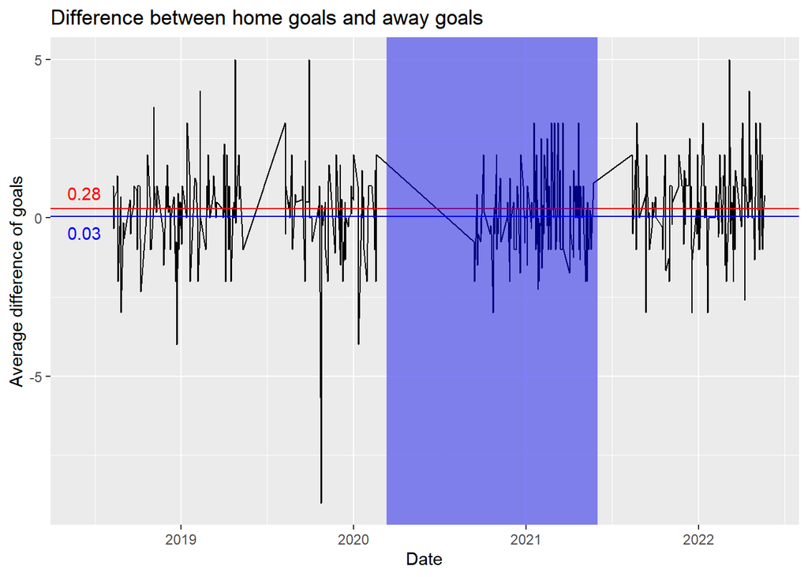

Figure 1 : Difference between home goals and away goals

The red line is clearly above zero and the corresponding mean is equal to 0.28, which means that in average when games are played with supporters, the home team scores 0.28 more goals than the away team. The blue line however that only takes in account the COVID-19 period is close to zero (0.03), which would mean that there is a very little or no effect in playing home rather than away when the stadiums are empty.

In the next section, we model the data to gain a deeper understanding of the extent to which the home advantage persisted during the COVID-19 pandemic. As a first definition of home advantage, we primarily examine the impact of playing at home on a team’s goal scoring ability with a poisson model. Secondly, we use the match results (win or loose) to build another poisson model. Our analysis aims to provide robust evidence on the impact of playing without fans and whether it affected the home advantage in the English Premier League.

# 3. Model building

## a. Poisson model for the number of goals

Home advantage can manifest in various forms, and we consider one indicator to be a team scoring more goals when playing at home. We construct separate Poisson models for each COVID-19 period (before, during, and after) to evaluate the effect of playing at home on a team’s goal scoring ability. Specifically, we assess whether there is a statistically significant difference in the number of goals scored by a team when playing at home compared to away during each period.

The data set contains a lot of variables, but we are only interested in this subsection in the number of goals scored. All teams are of the same league so the variable is irrelevant. Match statistics available are mostly a consequence of the home advantage so we don’t use them neither in this model because we want to identify the home-advantage ‘causal’ effect [4] [5]. Those statistics variables may be highly correlated with the number of goals but they do not have an explanatory power regarding the issue of home advantage and scoring ability of the teams.

To be able to interpret the coefficients as causal, we thus only regress the number of goals on the variable that specifies if the team is playing away or at home. We do not include cross effects with other variables.

The estimated coefficient associated with the home team is given in the following table :

*Table1 : Estimated coefficients for the number of goals*

|  | Estimate | Std.Error | t value | Pr(>\|t\|) | 2.5% | 97.5% |
| --- | --- | --- | --- | --- | --- | --- |
| Before covid | 0.19 | 0.048 | 4.08 | 4.43e-05 | 0.10 | 0.29 |
| During covid | 0.008 | 0.06 | 0.13 | 0.90 | -0.12 | 0.13 |
| After covid | 0.15 | 0.06 | 2.41 | 0.016 | 0.027 | 0.27 |

The equation for this model can be written $log(\mathbb{E}(N_{goals})) = \gamma_{0} + \gamma_{1}Home + \epsilon$

where $\gamma_{1}$ is the estimated coefficient associated to playing home rather than away, $\epsilon$ is the residual, $Home$ denotes the fact that the teams plays home and $N_{goals}$ is the number of goals.

## b. Poisson model for the number of wins

In this section, we explore whether home teams have an advantage in terms of winning matches. To this end, we consider the same three periods (before, during, and after COVID-19) and estimate the coefficient associated with playing at home on our count data. This approach provides an alternative perspective on the home advantage phenomenon, which can help us to gain a more comprehensive understanding of the impact of playing at home in the English Premier League. Again, we only include the variable corresponding to playing home or away in the set of explanatory variables for the reasons explained in 3.a.

Table 2 displays the results.

*Table2 : Estimated coefficients for the number of wins*

|  | Estimate | Std.Error | t value | Pr(>\|t\|) | 2.5% | 97.5% |
| --- | --- | --- | --- | --- | --- | --- |
| Before covid | 0.32 | 0.09 | 3.57 | 0.0003 | 0.15 | 0.5 |
| During covid | -0.06 | 0.12 | -0.52 | 0.6 | -0.28 | 0.17 |
| After covid | 0.23 | 0.12 | 1.99 | 0.047 | 0.004 | 0.47 |

The equation for this model can be written $log(\mathbb{E}(N_{wins})) = \beta_{0} + \beta_{1}Home + \zeta$

where $\beta_{1}$ is the estimated coefficient associated to playing home rather than away, $\zeta$ is the residual, $Home$ denotes the fact that the teams plays home and $N_{wins}$ is the number of wins.

# 4. Residuals diagnostics

The residuals for the other periods (during COVID-19, after COVID-19 and between 2018 and 2019) are very similar and available in the code for the reader.

The residuals for the poisson model on the number of goals are also very similar and identify the same amount of influential outliers. The plots are also available in the code for the reader.

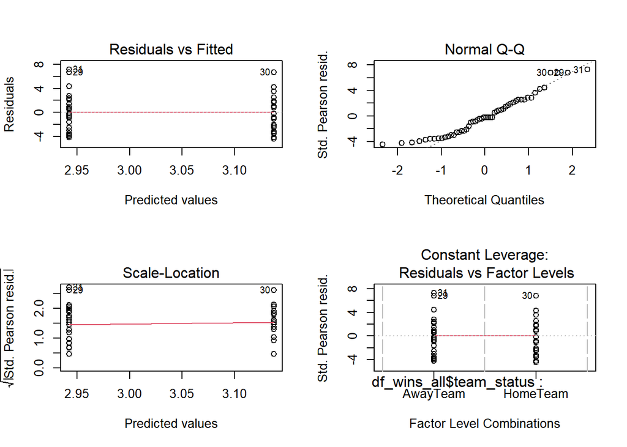

Figure 2: Residuals diagnostics for the wins model before covid

# 5. Stability

## a. Promoted and relegated teams

The models we have built so far have not taken into account the fact that some teams are relegated and others are promoted from season to season, which could potentially impact the estimates of the coefficients. To address this, we discard those teams and refit the Poisson model described in Part 3.b. This new model takes into account only the teams that have participated in all four seasons, and the estimated coefficients are based on these teams only. The estimated coefficients for the remaining teams are presented in the following table:

*Table 3 : Estimated coefficients of the Poisson model without relegated and promoted teams*

|  | Estimate | Std.Error | t value | Pr(>\|t\|) |
| --- | --- | --- | --- | --- |
| Before covid | 0.28 | 0.1 | 2.86 | 0.004 |
| During covid | -0.07 | 0.13 | -0.51 | 0.61 |
| After covid | 0.29 | 0.13 | 2.29 | 0.02 |

## b. Draw effect

Another limitation of the model described in Part 3.b is that we only counted the number of wins, but we could also include the draws as a “victory” for both teams. By doing this, we can account for the so-called “draw effect”, which is the tendency of home teams to draw more often than away teams. This effect could potentially impact the estimates of the coefficients. To address this issue, we refit the Poisson model by counting draws as 0.5 wins for both teams. The estimated coefficients for this modified model are presented in the table below :

*Table 4 : Estimated coefficients of the Poisson model taking in account the draws*

|  | Estimate | Std.Error | t value | Pr(>\|t\|) |
| --- | --- | --- | --- | --- |
| Before covid | 0.25 | 0.08 | 3.19 | 0.001 |
| During covid | -0.05 | 0.10 | -0.46 | 0.64 |
| After covid | 0.18 | 0.10 | 1.74 | 0.08 |

# 6. Interpretation

# 7. Discussion

The models developed show a disappearance of home advantage during the COVID-19 pandemic due to the closure of public stadiums. Since the stadiums’ grass didn’t change, the most plausible explanation of this decrease is the absence of supporters that can influence the players and the referees. That hypothesis seems the most relevant since after the pandemic, the home advantage returned with the fans. The magnitude of the effect was generally similar although slightly smaller. Possible explanations for this slight decrease include teams becoming accustomed to playing in empty stadiums or changes in fan behavior before and after the pandemic.

We considered Poisson models in our work, but the mean was generally greater from the variance in all the data sets we built, which showed under dispersion. Taking it in account doesn’t change the estimated coefficients but can affect the p-value and therefore the significance of our models. We could use a negative binomial model or a quasi poisson specification to address this issue.

The diagnostics and stability analyses demonstrate the robustness of the models, which instills confidence in the results. However, as previously stated, some influential outliers were identified and can possibly slightly bias the models we built. As a deepening of this work, one could therefore refit the models without those outliers.

Another deepening would be to explore other definitions of the home advantage. Indeed, we did not explore the yellow and red cards, which was studied by Garicano and Palacios-Huertas [1], and that we could also model with a Poisson model. Additionally, while we analyzed the number of goals, it could also be interesting to investigate a wider indicator such as the number of targeted goals instead.

# 8. References

[1] Garicano, L. and Palacios-Huerta, I. (2001). “An empirical examination of multilateral bargaining.” American Economic Review, 91(4): 828-848.

[2] Nevill, A. M., Newell, S. M., & Gale, S. (1996). Factors associated with home advantage in English and Scottish soccer matches. Journal of Sports Sciences, 14(2), 181-186.

[3] Pollard, R., & Pollard, G. (2005). Home advantage in soccer: Variations in its magnitude and a literature review of the inter-related factors associated with its existence. Journal of Sport Behavior, 28(3), 169-189.

[4] Stensrud M, ‘Randomization and Causation’ course, EPFL

[5] Davezzies L, Visser M, Lapenta E, D’Hautefoeuille X, ‘Econometrics 1’ and ‘Econometrics 2’ course, ENSAE Paris